# Avoid rush hours in Southern area of San Francisco, especially Fridays and Saturdays in August

## Problem discription

The goal of this study is to show that Southern area of San Francisco is the place that has the most frequent occurence of crimes. In this area, the occurence of the crimes peaks at rush hour (17pm and 18pm), and this rate is especially high on Fridays an Saturdays in August.

## R code for visualization

R code is used to visualize and analyze the data. ggplot2 package and reshape is required. Below is the R code for visualization. g1, g2, g3 and g4 are the objects of the graphs.

```
library(reshape)
library(ggplot2)
sf_inc <- read.csv('sanfrancisco_incidents_summer_2014.csv',
                   stringsAsFactor = FALSE);
HourMin <- strsplit(sf_inc$Time, split=":");
Date <- strsplit(sf_inc$Date, split="/");
dataSz <- dim(sf_inc)[1];
hours <- rep(NA, dataSz);
month <- rep(NA, dataSz);

for (k in 1:dataSz) {
    hours[k] <- HourMin[[k]][1]
    month[k] <- Date[[k]][1]

}
sf_inc$hours <- hours;
sf_inc$month <- month;
#loc<-sf_inc[sf_inc$hours == '18' | sf_inc$hours == '17', ]$PdDistrict
district<-sf_inc$PdDistrict
district_table <- as.data.frame(table(district));
g1 <- ggplot(district_table, aes(district, Freq)) + geom_bar(stat="identity")+coord_flip()+
     ggtitle(expression(atop("frequency distribution of crime in different districts")))

southern_hours <- sf_inc[sf_inc$PdDistrict == 'SOUTHERN',]$hours;
southern_hours_table <- as.data.frame(table(southern_hours))
colnames(southern_hours_table)[1] <- 'hours'
g2 <- ggplot(southern_hours_table, aes(hours, Freq)) + geom_bar(stat="identity") +
    ggtitle(expression(atop("frequency distribution of crime during a day")))


southern_hours_06 <-  sf_inc[sf_inc$PdDistrict == 'SOUTHERN' & sf_inc$month == '06',]$hours;
southern_hours_06_table <- as.data.frame(table(southern_hours_06))
colnames(southern_hours_06_table)[1] <- 'hours'
southern_hours_06_table$month <- rep('June', dim(southern_hours_06_table)[1])
southern_hours_07 <-  sf_inc[sf_inc$PdDistrict == 'SOUTHERN' & sf_inc$month == '07',]$hours;
southern_hours_07_table <- as.data.frame(table(southern_hours_07))
colnames(southern_hours_07_table)[1] <- 'hours'
southern_hours_07_table$month <- rep('July', dim(southern_hours_07_table)[1])
southern_hours_bymonth_table <- rbind(southern_hours_06_table, southern_hours_07_table)

southern_hours_08 <-  sf_inc[sf_inc$PdDistrict == 'SOUTHERN' & sf_inc$month == '08',]$hours;
southern_hours_08_table <- as.data.frame(table(southern_hours_08))
colnames(southern_hours_08_table)[1] <- 'hours'
southern_hours_08_table$month <- rep('Aug', dim(southern_hours_08_table)[1])
southern_hours_bymonth_table <- rbind(southern_hours_bymonth_table, southern_hours_08_table);
g3 <- ggplot(southern_hours_bymonth_table, aes(hours, Freq)) + geom_point(aes(color=month,shape=month)) +
    ggtitle(expression(atop("frequency distribution of crime for different months within each day")))



dayOfWeek_08 <-  sf_inc[(sf_inc$hours == '18' | sf_inc$hours == '17') & sf_inc$PdDistrict == 'SOUTHERN' & sf_inc$month == '08',]$DayOfWeek
dayOfWeek_08_tbl <-  as.data.frame(table(dayOfWeek_08))
colnames(dayOfWeek_08_tbl)[1] <- 'DayOfWeek'
dayOfWeek_08_tbl$dayOfWeek <- factor(dayOfWeek_08_tbl$DayOfWeek, levels = c('Monday', 'Tuesday', 'Wednesday', 'Thursday',
                                    'Friday', 'Saturday', 'Sunday'), ordered = TRUE);
g4 <- ggplot(dayOfWeek_08_tbl, aes(dayOfWeek, Freq)) + geom_bar(stat="identity") + coord_flip() +
 ggtitle(expression(atop("frequency distribution of crime during rush hour in a week in August")))
```

## Supporting evidence from the data

The first supporting evidence is that, in general, the crime rate in Southern area of San Francisco is higher than those of other areas.

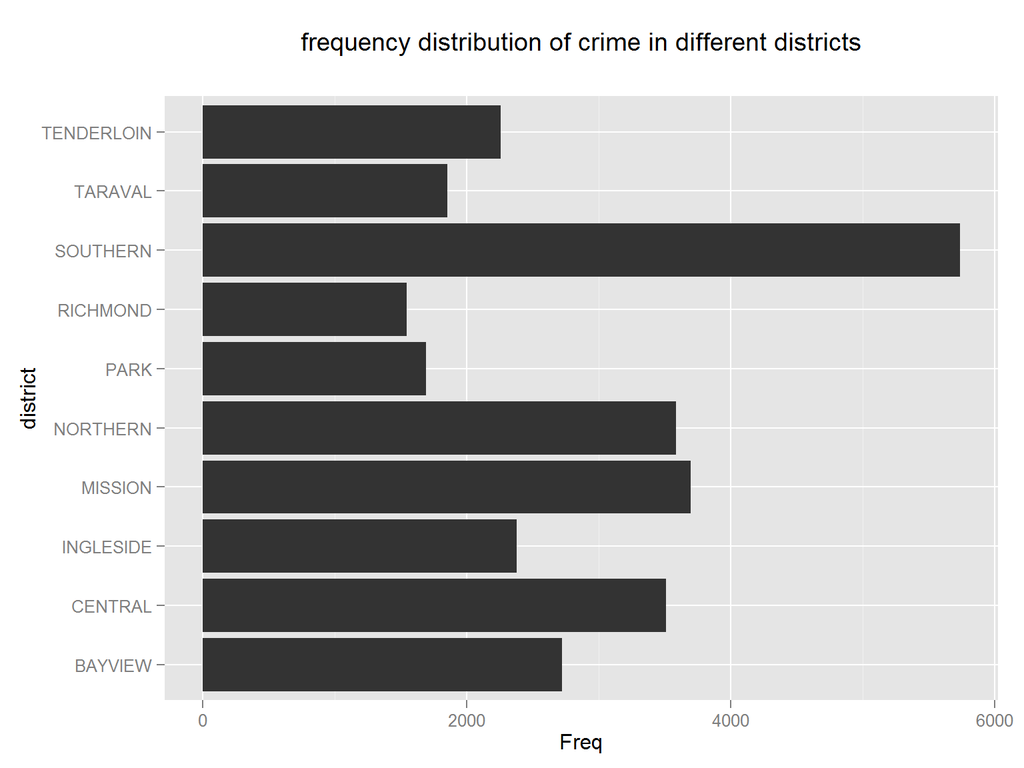

```r
g1
```

More detailed daily data shows that, in Southern areas, the crime rate peaks during rush hour, which is 17pm and 18 pm.

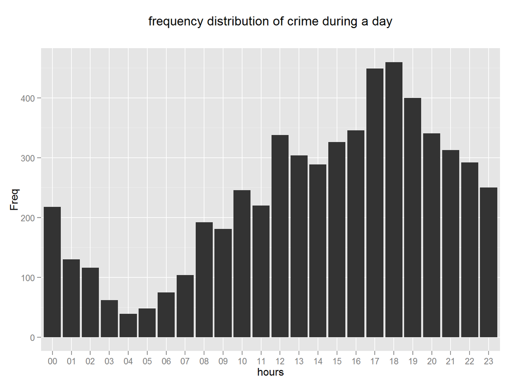

```r
g2
```

To show more details, the data from June to Auguest are visualized, which shows the increase of crime rate in August.

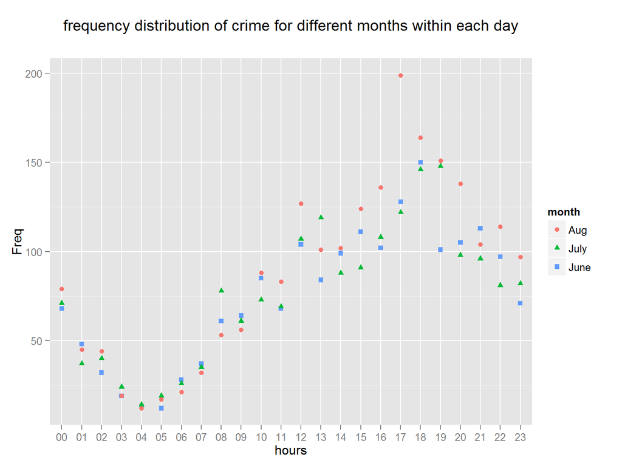

```r
g3
```

Also, for the rush hour in each week, the statistical data shows that the crime rates are higher on Fridays and Saturdays. Here call 17pm and 18pm for Saturday as “rush hour” too.

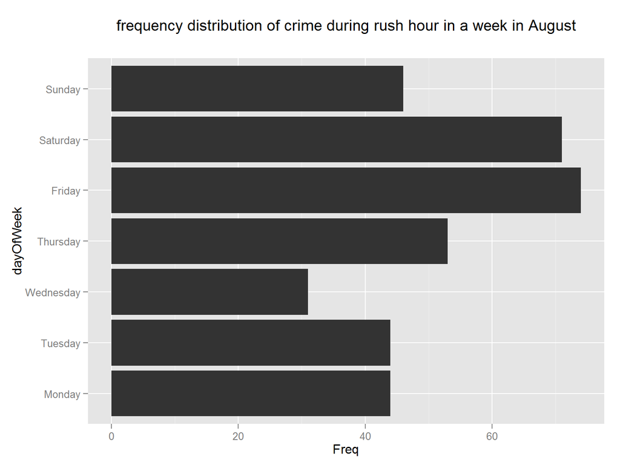

```r
g4
```